# PShaji_Assignment11

Priya Shaji

11/9/2019

Step 1) Load the built-in dataset of R: `cars`

Step 2) Display first few rows of `cars` dataset

```r
library(tidyverse)
head(cars)
```

|  | speed | dist |
| --- | --- | --- |
| 1 | 4 | 2 |
| 2 | 4 | 10 |
| 3 | 7 | 4 |
| 4 | 7 | 22 |
| 5 | 8 | 16 |
| 6 | 9 | 10 |

#### Visualization

Step 3) Let us now visualize our data

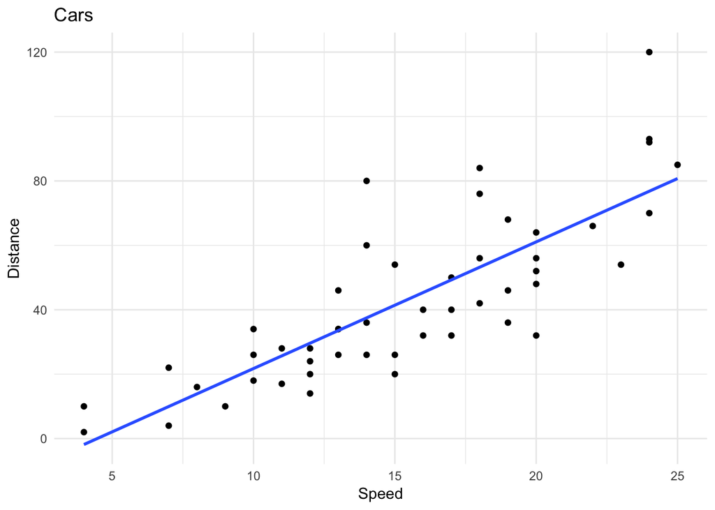

```r
cars %>%
  ggplot(aes(speed,dist)) +
  geom_point() +
  geom_smooth(method = lm,se = F)+
  labs(title = "Cars",
       x = "Speed", y = "Distance") +
  theme_minimal()
```

In the scatter plot above: there is positive linear trend between speed and distance.

```r
cars_lm <- lm(speed ~ dist, data = cars)
cars_lm
```

```
##
## Call:
## lm(formula = speed ~ dist, data = cars)
##
## Coefficients:
## (Intercept)         dist
##      8.2839       0.1656
```

#### Quality evaluation of the model

Step 5) Summary of the linear model : `cars_lm`

```r
summary(cars_lm)
```

```
##
## Call:
## lm(formula = speed ~ dist, data = cars)
##
## Residuals:
##     Min      1Q  Median      3Q     Max
## -7.5293 -2.1550  0.3615  2.4377  6.4179
##
## Coefficients:
##             Estimate Std. Error t value Pr(>|t|)
## (Intercept)  8.28391    0.87438   9.474 1.44e-12 ***
## dist         0.16557    0.01749   9.464 1.49e-12 ***
## ---
## Signif. codes:  0 '***' 0.001 '**' 0.01 '*' 0.05 '.' 0.1 ' ' 1
##
## Residual standard error: 3.156 on 48 degrees of freedom
## Multiple R-squared:  0.6511, Adjusted R-squared:  0.6438
## F-statistic: 89.57 on 1 and 48 DF,  p-value: 1.49e-12
```

The summary of the linear regression model shows that min-max and 1Q-3Q has approximately similar magnitudes and the median is close to zero.

The p-value shows that the probability of this variable is very low to be considered irrelevant.

R-squared is 0.65, which means this model explains 65% of the data’s variation. Therefore,this is a good model.

#### Residual analysis

Step 6) Let’s build a residual plot for our linear model

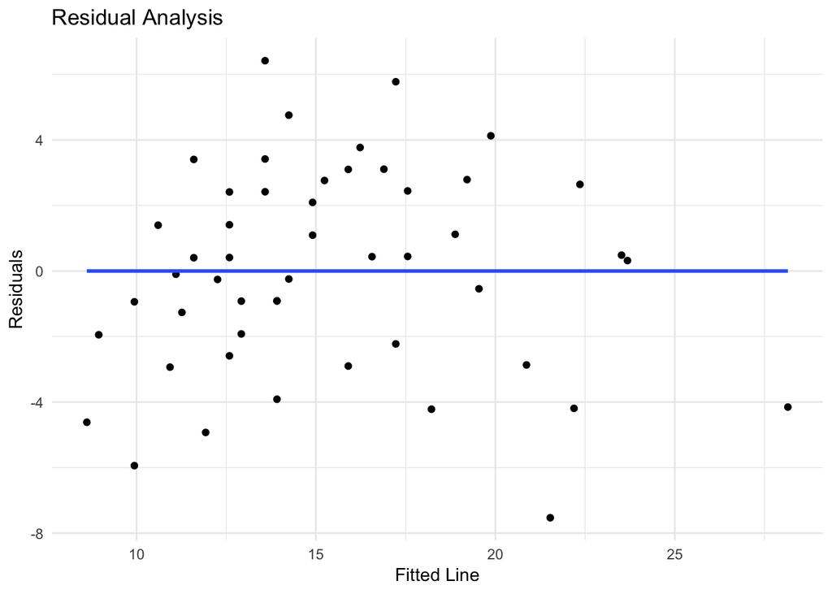

```r
cars_lm %>%
  ggplot(aes(fitted(cars_lm), resid(cars_lm))) +
  geom_point() +
  geom_smooth(method = lm, se =F) +
  labs(title = "Residual Analysis",
       x = "Fitted Line", y = "Residuals") +
  theme_minimal()
```

Step 7) Plot the Q-Q plot

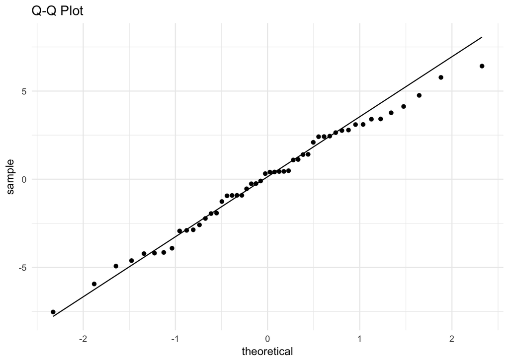

```r
cars_lm %>%
  ggplot(aes(sample = resid(cars_lm))) +
  stat_qq() +
  stat_qq_line() +
  labs(title = "Q-Q Plot") +
  theme_minimal()
```

As we see in the residual plot above, variance of residuals are not uniform whcih tells that our explanatory variable does not fully explain the data. But if we look at the quartile-quartile plot, we see that the residulas are normally distributed. Therefore, overall this is a good model.